# visual data in R

# Making plots with ggplot package

Story

You are working with a professor of anthropology at Fancypants University. She has just discovered a new species of monkey that she wants you to collect data on. So you are off to the island of Naboombu, where you will be given the task of watching these primates.

## Collecting your data, part 1

When you arrive you notice that there are a whole lot of monkeys here and you need to find a way to get an idea of what they look like. So you and your team decide to start by measuring their tails (they aren’t apes!). you manage to measure 500 of these fellas (ok, this is a bit of a reach but lets say that you are *really* quick at measuring)

run the following R code to get the first monkey data! Be sure to run the first line of code that loads in the library. I made some comments so you can follow along with the data.

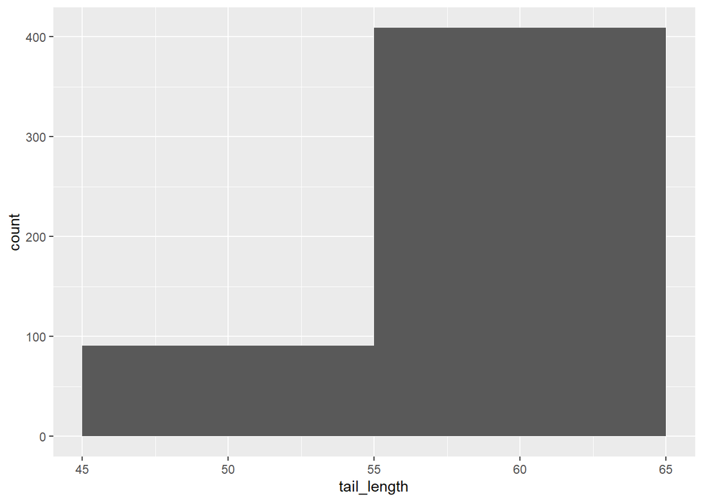

```r
library(tidyverse)
set.seed(2020) #this sets the randomizer in R
tail_length <-rnorm(500,57,2) # create a set of 500 random numbers with a mean of 57 and a standard deviation of 2
sample_number <-1:500 # create a vector of numbers from 1 to 500
monkey_pop <- rep(letters[1], 500) # this makes a vector of 500 'a's
monkey_data_1 <- tibble(sample_number, tail_length, monkey_pop) #create a data table (a tibble is a function that makes nice data tables with a modern flair...)

monkey_data_1 %>%  ggplot(aes(tail_length)) + geom_histogram(binwidth =  10) # this takes the monkey data and plots a histogram of the tail length
```

### Question 1: changing the bin length:

you note that the plot you made with the code above doesn’t look very nice. After thinking for a bit you realize the bin length is too large. What code would you use to change the binwidth to be 1

> copy your answer to question 1 here:

### Question 2: Ok, but she wants the histogram to be blue. How can you add to the code below to make it blue?

```r
#copy your answer to question 2 here:
```

After sending your data to your professor you hear about another group of monkeys on a different part of the island run the code below to get that data and make a histogram!

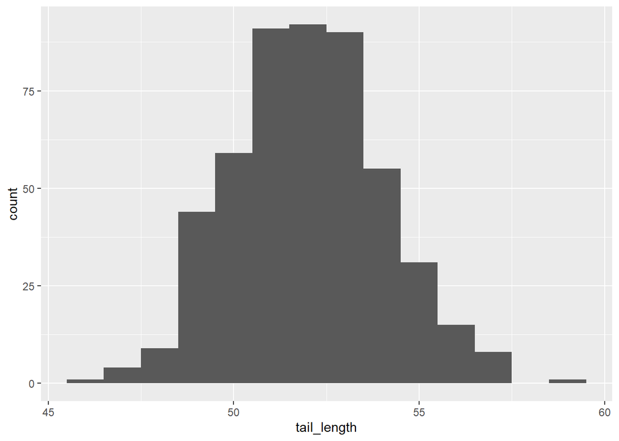

```r
tail_length <-rnorm(500,52,2)
sample_number <-501:1000
monkey_pop <- rep(letters[2], 500)
monkey_data_2 <- tibble(sample_number, tail_length, monkey_pop)

monkey_data_2 %>%  ggplot(aes(tail_length)) + geom_histogram(binwidth =  1)
```

Now you want to look at both of the populations at the same time! Thankfully you have taken this class and have some R code ready to do this:

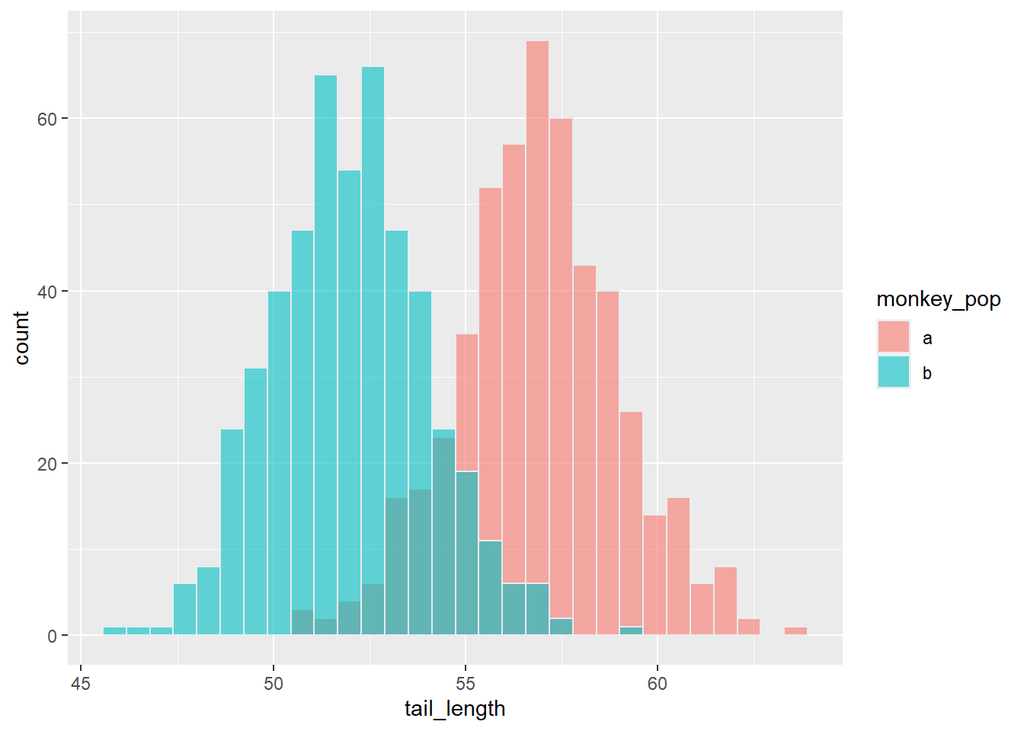

```r
all_data <- bind_rows(monkey_data_1, monkey_data_2)

all_data %>% ggplot(aes(tail_length, fill=monkey_pop )) + geom_histogram(color="#e9ecef", alpha=0.6, position = 'identity')
```

So you look at this and think to yourself “hey, they overlap a bit but there are difference at the tails. I am going to send this to my adviser and she will be soooooo happy!”

A few hours later you get an email with these requests. Your adviser wants you to do all of the following to the figure you have made

### Question 2

- Put the legend on the bottom rather than on the right
- Label the x axis “tail length (cm)”
- Label the y axis “number of observations”
- Give it a title that is meaningful
- Put a credit somewhere that says who made the figure
- Change the legend so that it says “Monkey groups”
- Change the labels from “a” and “b” to “Group one” and “Group 2”

Lets take this step by step. copy the below R code and use each step to build the new graph. If you need help use the class readings or ask on Discord! Then copy the code you used into your homework file for this assignment.

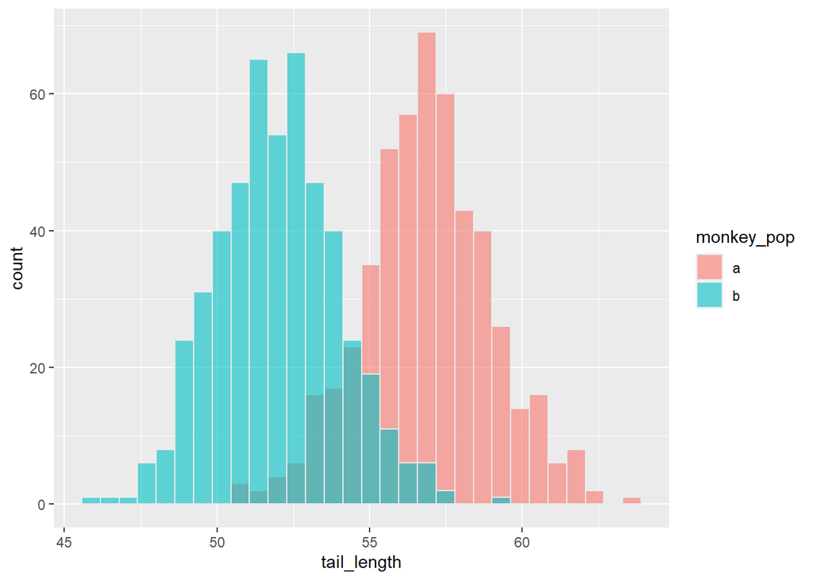

```r
all_data %>% ggplot(aes(tail_length, fill=monkey_pop )) + geom_histogram(color="#e9ecef", alpha=0.6, position = 'identity')
```

## New data

You and your professor submit your data to a journal. After a few weeks you get your peer review back and the reviewers say “wow, this is cool! but ya know what, we think you need more measurements before we can conclude these are 2 different populations. can you go and measure ear length?”

copy and Run the following code to get the new_data

```r
ear1 <- rnorm(500, 4.4, .22)
ear2 <- rnorm(500, 6.3, .31)

ear1 <-tibble(ear =rnorm(500, 4.4, .22), monkey_pop = rep(letters[1], 500), sample_number = 1:500)


ear2 <-tibble(ear =rnorm(500, 6.3, .31), monkey_pop = rep(letters[2], 500), sample_number = 501:1000)

ear_all <- bind_rows(ear1, ear2)

new_data <- all_data %>% left_join(ear_all, by= c("monkey_pop", "sample_number"))
```

Since you know have two measurements on each monkey you need a new way to visualize these data. Remembering what you learned at AppState you go and make a scatterplot of these data:

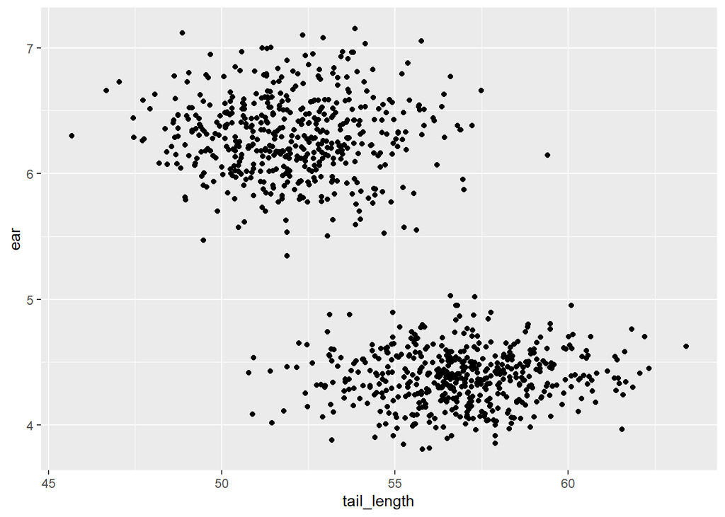

```r
new_data %>%   ggplot(aes(tail_length, ear)) + geom_point()
```

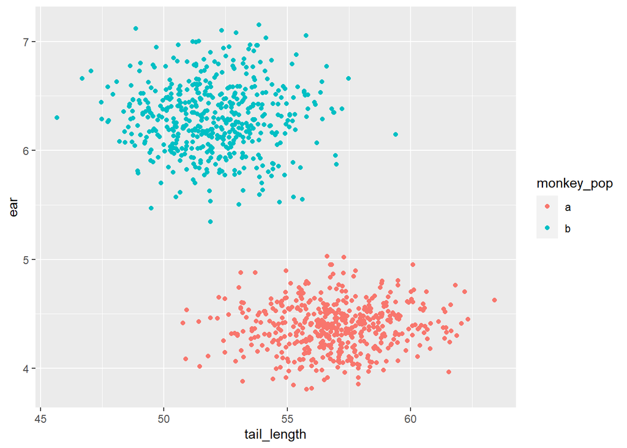

```r
new_data %>%   ggplot(aes(tail_length, ear, color = monkey_pop)) + geom_point()
```

She comes back and asks for the following updates:

### Question three:

- Get rid of the legend
- Add a regression line for each group
- Add a transparency o deal with over plotting
- Change the shape so that each group has a different shape
- Add an ellipse to the groups (s**tat_ellipse()**

### Question four

Your adviser now asks if you can make the plots with a different geom

- make a density plot
- make a ridgeline plot
- make a boxplot
- make a violin plot

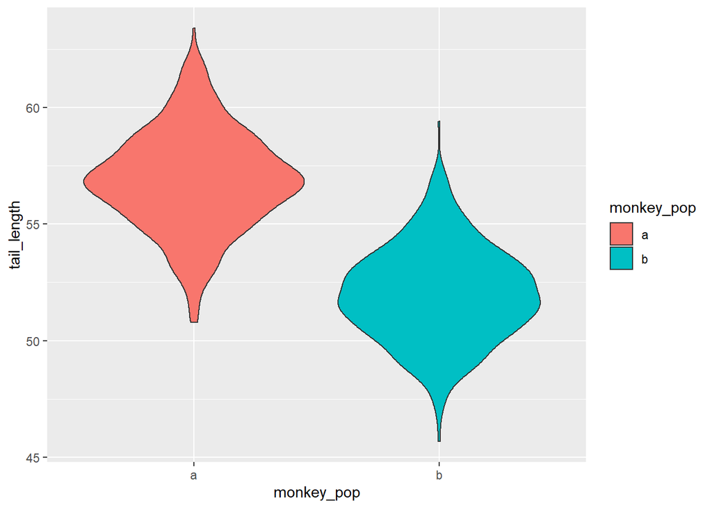

```r
new_data %>%   ggplot(aes( monkey_pop, tail_length, fill = monkey_pop)) + geom_violin()
```

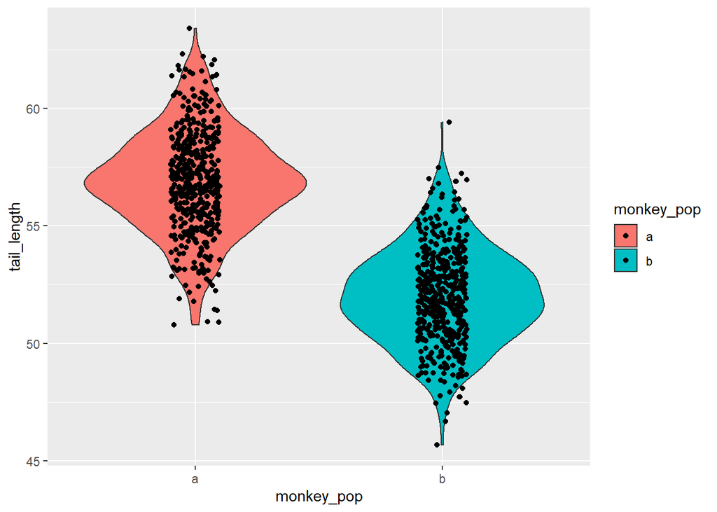

```r
new_data %>%   ggplot(aes(monkey_pop, tail_length, fill = monkey_pop)) + geom_violin()+ geom_jitter(height = 0, width = 0.1)
```

## export the data

she wants the whole dataset sent to her so she can take a look at it herself

### Question four

- change the name of the csv file so it is called “new_primate_data”?
- change the format of the exported file to an Excel sheet (this is hard)

```r
write_csv(new_data, "my_monkeydata.csv")
```

## What else can you do with R visualizations

Now that you have learned a lot about how to work with visualization data i want you to take a moment and think about how to approach another dataset

The palmerpenguins package contains two datasets.

One is called `penguins`, and is a simplified version of the raw data; see [`?penguins`](https://allisonhorst.github.io/palmerpenguins/reference/penguins.html) for more info

The second dataset is `penguins_raw`, and contains all the variables and original names as downloaded; see [`?penguins_raw`](https://allisonhorst.github.io/palmerpenguins/reference/penguins_raw.html) for more info.

Both datasets contain data for 344 penguins. There are 3 different species of penguins in this dataset, collected from 3 islands in the Palmer Archipelago, Antarctica. The culmen is the upper ridge of a bird’s bill. In the simplified penguins data, culmen length and depth are renamed as variables bill_length_mm and bill_depth_mm to be more intuitive.

```r
#install.library("palmerpenguins")
library(palmerpenguins)
penguins %>%
  count(species)
```

```
## # A tibble: 3 x 2
##   species       n
##   <fct>     <int>
## 1 Adelie      152
## 2 Chinstrap    68
## 3 Gentoo      124
```

```
#> # A tibble: 3 x 2
#>   species       n
#>   <fct>     <int>
#> 1 Adelie      152
#> 2 Chinstrap    68
#> 3 Gentoo      124
```

```r
penguins %>%
  group_by(species) %>%
  summarize(across(where(is.numeric), mean, na.rm = TRUE))
```

```
## # A tibble: 3 x 6
##   species   bill_length_mm bill_depth_mm flipper_length_mm body_mass_g  year
##   <fct>              <dbl>         <dbl>             <dbl>       <dbl> <dbl>
## 1 Adelie              38.8          18.3              190.       3701. 2008.
## 2 Chinstrap           48.8          18.4              196.       3733. 2008.
## 3 Gentoo              47.5          15.0              217.       5076. 2008.
```

think about what the above code is doing?

```r
install.packages("palmerpenguins")
library(palmerpenguins)
glimpse(penguins)
```

```
## Rows: 344
## Columns: 8
## $ species           <fct> Adelie, Adelie, Adelie, Adelie, Adelie, Adelie, A...
## $ island            <fct> Torgersen, Torgersen, Torgersen, Torgersen, Torge...
## $ bill_length_mm    <dbl> 39.1, 39.5, 40.3, NA, 36.7, 39.3, 38.9, 39.2, 34....
## $ bill_depth_mm     <dbl> 18.7, 17.4, 18.0, NA, 19.3, 20.6, 17.8, 19.6, 18....
## $ flipper_length_mm <int> 181, 186, 195, NA, 193, 190, 181, 195, 193, 190, ...
## $ body_mass_g       <int> 3750, 3800, 3250, NA, 3450, 3650, 3625, 4675, 347...
## $ sex               <fct> male, female, female, NA, female, male, female, m...
## $ year              <int> 2007, 2007, 2007, 2007, 2007, 2007, 2007, 2007, 2...
```

take a look at these data. what sort of figures might you want to make? think about how you could tell a story about these penguins via an image. then write some code that will let you do this. when you are done, take a moment to explain in prose why you made this figure and how you used R to do it